# Co znaczy około - ankieta?

Paweł Lonca

5 czerwca 2018

```r
library(dplyr)
```

```r
library(ggplot2)
library(purrr) # map()
library(tidyr) # unnest()
```

Link do ankiety został umieszczony na grupie Kognitywistyka 2016-2019 w serwisie Facebook:

[figure not shown]

Osoby badane miały do wypełnienia następujący formularz ([link](https://docs.google.com/forms/d/e/1FAIpQLSdNnpk-zCHJPShP8hkoJjVf35lOU3AhRPSIXPuqKaqa5jcUiw/viewform)):

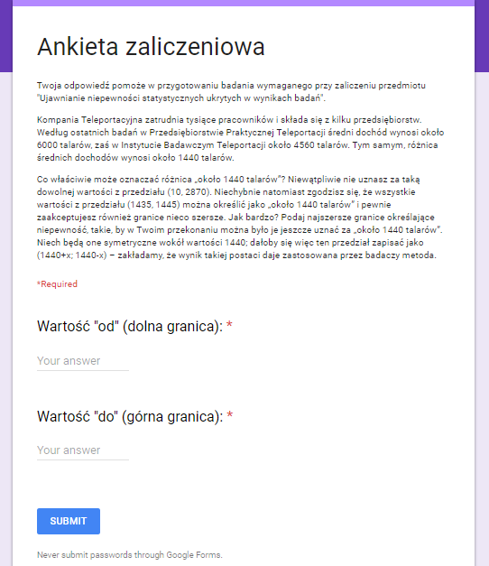

Zebrane na podstawie internetowej ankiety dane:

```r
ankietowe <- read.csv("ankieta_google.csv")
head(ankietowe)
```

```
##                  time dolna gorna
## 1 30/05/2018 15:35:45  1400  1480
## 2 30/05/2018 15:42:12  1340  1540
## 3 30/05/2018 15:42:28  1000  1880
## 4 30/05/2018 15:42:37  1430  1450
## 5 30/05/2018 15:42:39  1430  1450
## 6 30/05/2018 15:42:51  1380  1500
```

Usuwam kolumnę ze znacznikiem czasu:

```r
ankietowe$time <- NULL
```

Sprawdzenie czy granice podane przez ankietowanych są symetryczne wokół wartości 1440:

```r
ankietowane_poprawne <- ankietowe %>%
  mutate(rownosc = (gorna - dolna)/2 + dolna) %>%
  filter(rownosc == 1440) %>%
  mutate(roznica = (gorna - dolna)/2) %>%
  dplyr::select(roznica) %>%
  arrange(desc(roznica))
```

Okazało się, że 3 odpowiedzi były wprowadzone niepoprawnie. Poniżej zostanie przeanalizowanych 25 odpowiedzi.

Boxplot dla kolumny opisującej połowę przedziału wskazanego przez ankietowanych:

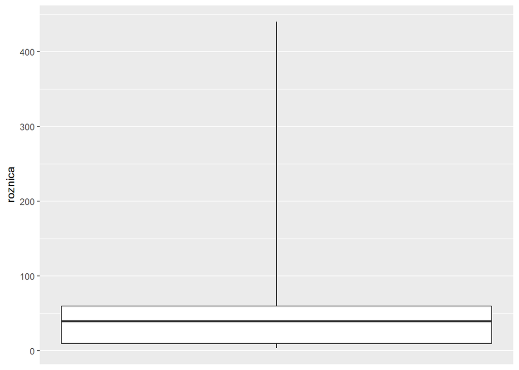

```r
ggplot(ankietowane_poprawne, aes(x = 1, y = roznica)) + geom_boxplot(coef = Inf) +
  scale_x_continuous(breaks=NULL) +
  theme(axis.title.x = element_blank())
```

Histogram dla tej samej kolumny:

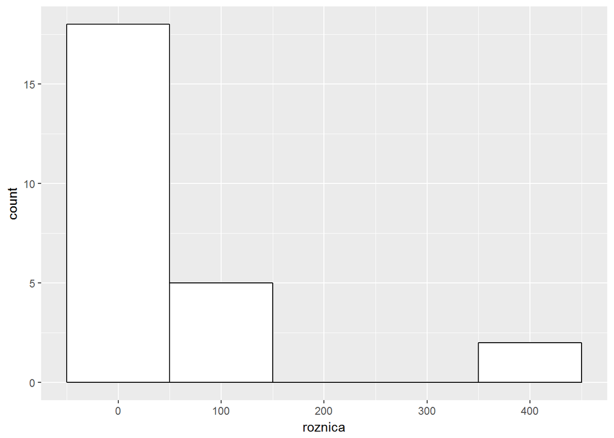

```r
ggplot(ankietowane_poprawne, aes(roznica)) + geom_histogram(binwidth  = 100,
                                                            fill="white",
                                                            colour="black")
```

Jako, że jest mało obserwacji możemy sobie pozwolić na zliczenie poszczególnych poziomów odpowiedzi. Najwięcej respondentów (5) wskazało na połowę różnicy wynoszącą:

```r
ankietowane_poprawne %>%
  count(roznica) %>%
  arrange(desc(n)) %>%
  `[[`(1,1)
```

```
## [1] 40
```

Tworzenie tabeli do wykresów. Na początku usuwam powtórzone wartości:

```r
ankietowane_unikalne <- ankietowane_poprawne %>% distinct(roznica)
```

Funkcja licząca przedział ufności dla zadanej liczebności próbki oraz poziomu alfa:

```r
odpowiedz = function(r = 1440, pol = 5, n, p){
  #roznica - różnica w płacach
  #pol - połowa roznicy wynikajacej z (gorny - dolny)
  #n - liczebność
  #p - p-value

  t0 = qt(1 - p/2, n - 1)
  odchylenie =  r * sqrt(n) / t0
  alfa = 2 * (1 - pt(pol * sqrt(n) / odchylenie, n - 1))
  return (round((1 - alfa), digits = 5))
}
```

```r
ramka_ufnosc <- function(roznica){
  ramka <- data.frame(nn = c(rep(10,3), rep(300, 3)),
                      p_val = rep(c(0.04, 0.009, 0.0001)),
                      conf = NA, D = roznica)
  ramka$conf <- odpowiedz(pol = ramka$D, n = ramka$nn, p = ramka$p_val)
  ramka
}
```

Tworzę teraz ramkę danych, która w kolumnie $przedzialy$ zawiera ramkę danych stworzoną w oparciu o funkcję powyżej:

```r
nested_ankietowane <- ankietowane_unikalne %>%
  mutate(przedzialy = map(roznica, ramka_ufnosc))
```

Dostęp do poszczególnych ramek następująco:

```r
nested_ankietowane$przedzialy[[5]]
```

```
##    nn p_val    conf  D
## 1  10 4e-02 0.06455 50
## 2  10 9e-03 0.08913 50
## 3  10 1e-04 0.17597 50
## 4 300 4e-02 0.05705 50
## 5 300 9e-03 0.07268 50
## 6 300 1e-04 0.10883 50
```

Tworzę normalną ramkę danych, którą można zgrupować według poszczególnych wartości liczebności oraz przedziałów ufności:

```r
unnested_przedzialy <- unnest(nested_ankietowane, przedzialy)
head(unnested_przedzialy, 8)
```

```
##   roznica  nn p_val    conf   D
## 1     440  10 4e-02 0.51770 440
## 2     440  10 9e-03 0.66256 440
## 3     440  10 1e-04 0.92525 440
## 4     440 300 4e-02 0.47101 440
## 5     440 300 9e-03 0.57761 440
## 6     440 300 1e-04 0.77085 440
## 7     140  10 4e-02 0.17916 140
## 8     140  10 9e-03 0.24547 140
```

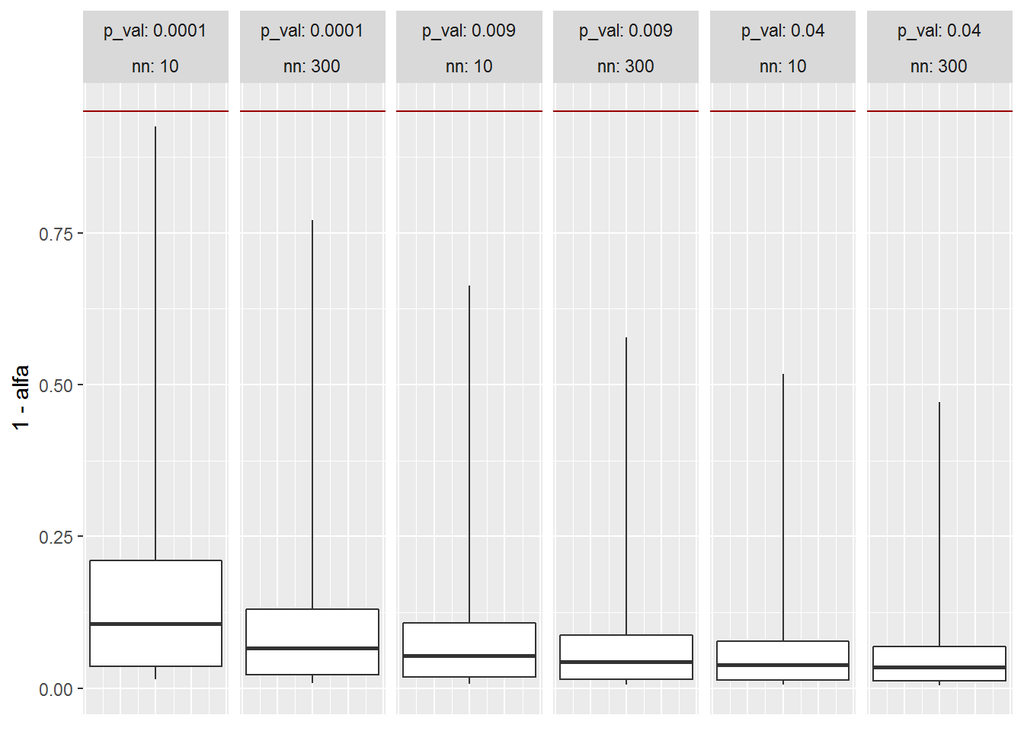

```r
options(scipen=999) #wyłącza notację naukową
ggplot(unnested_przedzialy, aes(x = 1, y = conf)) + geom_boxplot(coef = Inf) +
  labs(y = "1 - alfa") +
  geom_hline(aes(yintercept=0.95), colour="#990000") +
  theme(axis.title.x=element_blank(),
        axis.text.x=element_blank(),
        axis.ticks.x=element_blank()) +
  facet_grid(~ p_val + nn, labeller = label_context)
```

```r
options(scipen=0) #włącza notację naukową
```

```r
wartosci <- expand.grid(nn = c(10, 300), p_val = c(0.0001, 0.009, 0.04))

for (i in 1:nrow(wartosci)){
  wybrane_wartosci <- wartosci[i, ]

filtrowane <- unnested_przedzialy %>%
  filter(p_val == wybrane_wartosci[["p_val"]],
                               nn == wybrane_wartosci[["nn"]]) %>%
  mutate(D = 2*D, D_factor = as.factor(D))

eqn <- as.character(as.expression(
  substitute(1 - alfa == a, list(a = format(max(filtrowane$conf))))))

plot <- ggplot(filtrowane, aes(y=D_factor, x=conf, size = D)) +
  geom_point(stat = "identity") +
  scale_size_area(max_size=5) +
  scale_x_continuous(limits = c(0, 0.95)) +
  geom_segment(aes(yend = conf), xend = -10000, size = 0.5) +
  labs(x = "1 - alfa", y = "Rozpiętość około") + theme(legend.position="none") +
  annotate("text", label=eqn, parse=TRUE,
           x=Inf, y=-Inf, vjust = -2.5, hjust = 1.5, color = "#990000") +
  ggtitle(paste("wartość p:", wybrane_wartosci[["p_val"]], "\n", "liczebność:",
                wybrane_wartosci[["nn"]]))

assign(paste("p", i, sep = ""), plot)
}
```

W prawym dolnym rogu zaznaczona jest maksymalna wartość 1 - alfa dla poszczególnych podzbiorów.

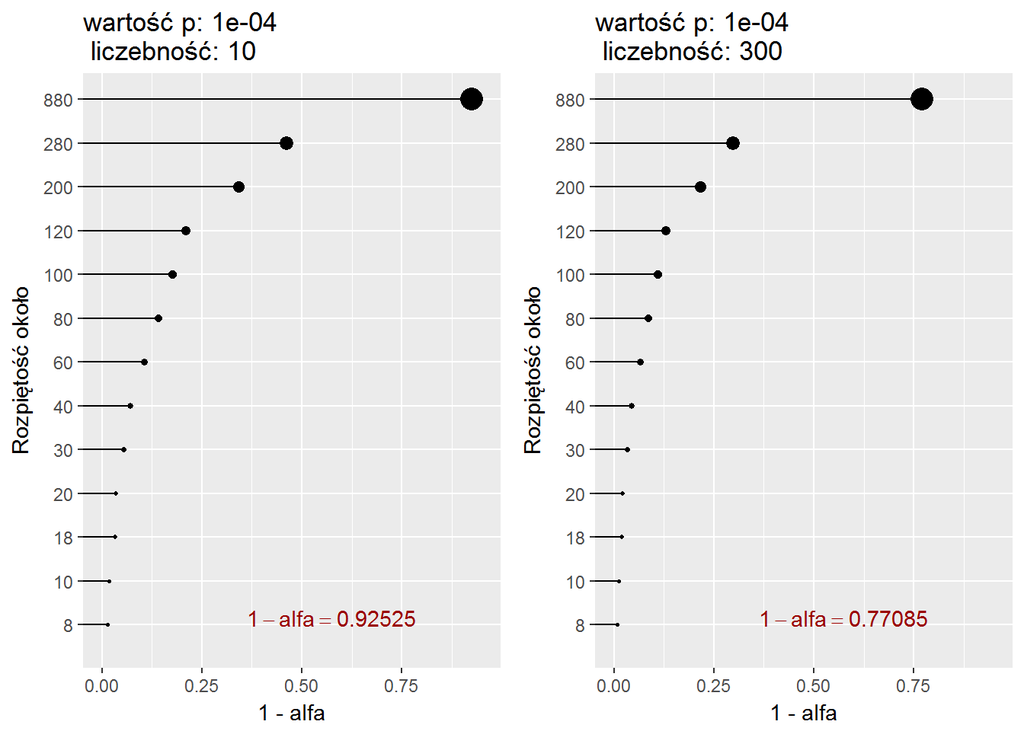

```r
gridExtra::grid.arrange(p1, p2, ncol = 2)
```

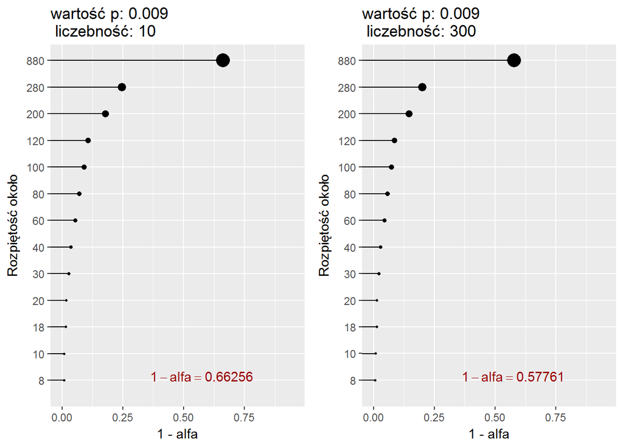

```r
gridExtra::grid.arrange(p3, p4, ncol = 2)
```

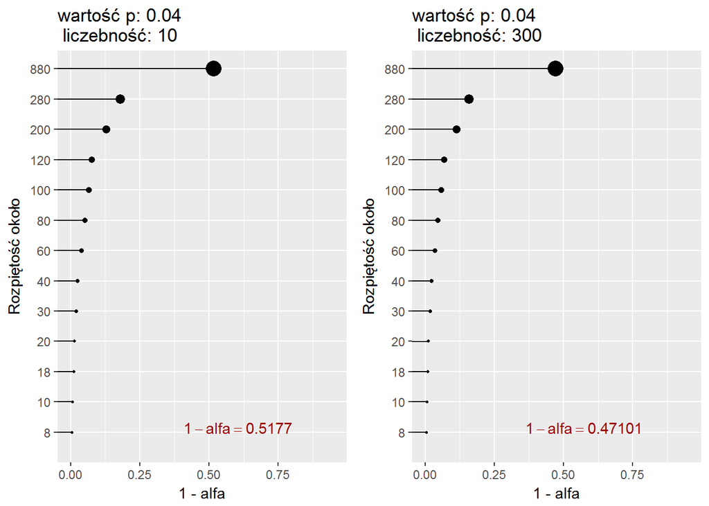

```r
gridExtra::grid.arrange(p5, p6, ncol = 2)
```